# Hand and Foot Analysis

Andrew Heiss

October 27, 2016

```r
knitr::opts_chunk$set(cache=FALSE, fig.retina=2,
                      tidy.opts=list(width.cutoff=120),  # For code
                      options(width=120))  # For output

# Load libraries and data
library(tidyverse)
library(pander)
library(scales)
library(broom)
library(forcats)

panderOptions('table.split.table', Inf)
panderOptions('table.split.cells', Inf)

theme_set(theme_light(base_family="Source Sans Pro"))

hf.df <- read_csv("hand_and_foot.csv")

round.details <- hf.df %>%
  mutate(score_round = score_books + score_cards) %>%
  group_by(game, round) %>%
  mutate(win_round = score_round == max(score_round)) %>%
  mutate(player_next = lead(player, default=player[1]),
         player_previous = lag(player, default=player[n()]))

game.details <- round.details %>%
  group_by(game, player) %>%
  summarise(score_total = sum(score_round)) %>%
  mutate(win_game = score_total == max(score_total))

hf.full <- round.details %>%
  left_join(game.details, by=c("game", "player"))
```

## Does going down first matter?

### What’s the probability of winning the round if you go down first?

```r
prob.win.first <- round.details %>%
  filter(!is.na(down_first)) %>%
  group_by(down_first) %>%
  summarise(win_round = sum(win_round)) %>%
  mutate(prob_win_round = percent(win_round / sum(win_round)))
```

There is a 54.17% chance of winning the round if you go down first.

```r
pandoc.table(prob.win.first)
```

| down_first | win_round | prob_win_round |
| --- | --- | --- |
| FALSE | 11 | 45.83% |
| TRUE | 13 | 54.17% |

### Is there a difference in the total number of points you get if you go down first?

```r
points.first <- round.details %>%
  filter(!is.na(down_first)) %>%
  group_by(down_first) %>%
  summarise(score_round_mean = mean(score_round),
            score_round_median = median(score_round))

points.first.test <- t.test(score_round ~ down_first, data=round.details) %>%
  tidy()
```

On average, going down first gives you 301.56 additional points (492.5 if you consider the median). This difference is not statistically significant, though, (t = -1.19, p = 0.24) and we cannot rule out the possibility that this difference is due to chance.

```r
pandoc.table(points.first)
```

| down_first | score_round_mean | score_round_median |
| --- | --- | --- |
| FALSE | 1369 | 1462 |
| TRUE | 1670 | 1955 |

## Does getting to your foot first matter?

### What’s the probability of winning the round if you get to your foot first?

```r
prob.win.foot <- round.details %>%
  filter(!is.na(foot_first)) %>%
  group_by(foot_first) %>%
  summarise(win_round = sum(win_round)) %>%
  mutate(prob_win_round = percent(win_round / sum(win_round)))
```

People who get their foot first win the round 37.5% of the time.

```r
pandoc.table(prob.win.foot)
```

| foot_first | win_round | prob_win_round |
| --- | --- | --- |
| FALSE | 15 | 62.5% |
| TRUE | 9 | 37.5% |

### Is there a difference in the total number of points you get if you get your foot first?

```r
points.foot <- round.details %>%
  filter(!is.na(foot_first)) %>%
  group_by(foot_first) %>%
  summarise(score_round_mean = mean(score_round),
            score_round_median = median(score_round))

points.foot.test <- t.test(score_round ~ foot_first, data=round.details) %>%
  tidy()
```

On average, getting to your foot first gives you 98.12 additional points (2.5 if you consider the median). This difference is not statistically significant, though, (t = -0.48, p = 0.64) and we cannot rule out the possibility that this difference is due to chance.

```r
pandoc.table(points.foot)
```

| foot_first | score_round_mean | score_round_median |
| --- | --- | --- |
| FALSE | 1436 | 1490 |
| TRUE | 1535 | 1492 |

## Does seating order matter?

```r
typical.round <- mean(round.details$score_round)

sitting.before <- round.details %>%
  group_by(player_next) %>%
  summarise(score_round_mean = mean(score_round),
            score_round_sd = sd(score_round)) %>%
  ungroup() %>%
  mutate(position = "Before") %>%
  rename(player = player_next)

sitting.after <- round.details %>%
  group_by(player_previous) %>%
  summarise(score_round_mean = mean(score_round),
            score_round_sd = sd(score_round)) %>%
  ungroup() %>%
  mutate(position = "After") %>%
  rename(player = player_previous) %>%
  mutate(diff_from_mean = score_round_mean - typical.round)

sitting <- bind_rows(sitting.before, sitting.after) %>%
  mutate(position = fct_relevel(position, "Before"))
```

Assuming an average of 1421.43 points per round, at first glance, it appears that sitting after Andrew gives you an average *increase* of 227.68 points, while sitting after Nancy *decreases* your score by 256.61 points. However, these differences are not statistically significant (phew) and could be due to chance.

There is no substantial difference in score when sitting before someone else.

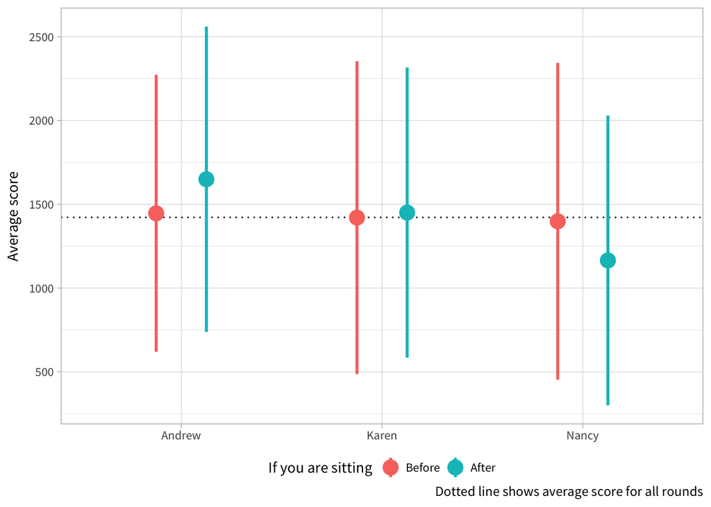

```r
ggplot(sitting, aes(x=player, y=score_round_mean, colour=position)) +
  geom_hline(yintercept=typical.round, linetype="dotted") +
  geom_pointrange(aes(ymin = score_round_mean - score_round_sd,
                      ymax = score_round_mean + score_round_sd),
                  size=1, position=position_dodge(width=0.5)) +
  guides(colour=guide_legend(title="If you are sitting")) +
  labs(x=NULL, y="Average score",
       caption="Dotted line shows average score for all rounds") +
  theme(legend.position="bottom")
```

## Do people score more in different rounds?

```r
round.totals <- round.details %>%
  group_by(round) %>%
  summarise(score_round_mean = mean(score_round),
            score_round_sd = sd(score_round),
            score_round_median = median(score_round)) %>%
  mutate(round = factor(round))
```

On average, it appears that people score more points in later rounds, though the difference between rounds is not statistically significant.

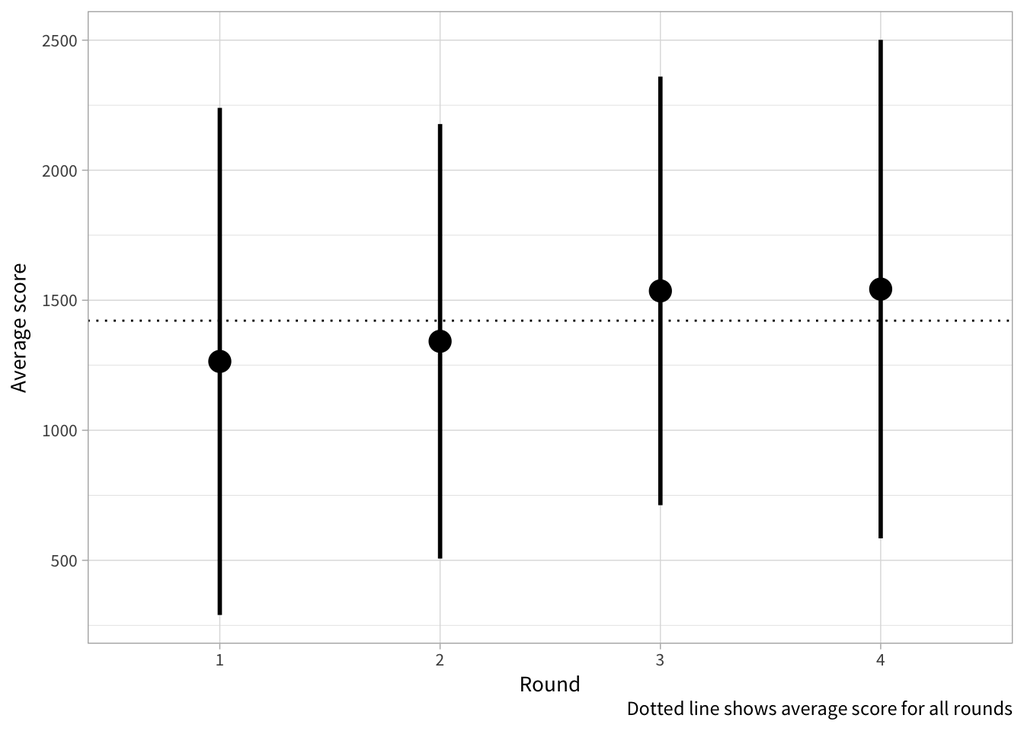

```r
ggplot(round.totals, aes(x=round, score_round_mean)) +
  geom_hline(yintercept=typical.round, linetype="dotted") +
  geom_pointrange(aes(ymin = score_round_mean - score_round_sd,
                      ymax = score_round_mean + score_round_sd),
                  size=1, position=position_dodge(width=0.5)) +
  labs(x="Round", y="Average score",
       caption="Dotted line shows average score for all rounds")
```

## How are book points, card points, and card piles related?

### Book points and card points

Unsurprisingly, the number of points you score in cards is closely related to the number of points you score with books.

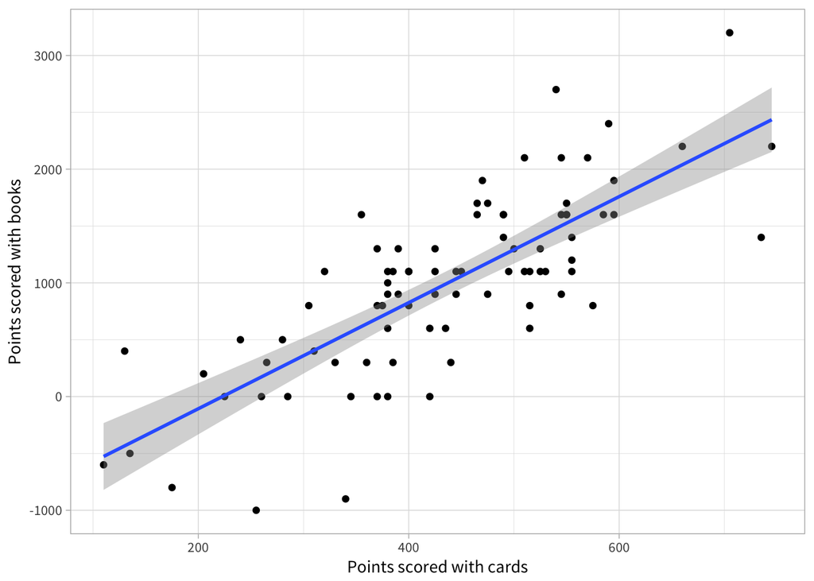

```r
ggplot(round.details, aes(x=score_cards, y=score_books)) +
  geom_point() +
  geom_smooth(method="lm") +
  labs(x="Points scored with cards", y="Points scored with books")
```

### Book points and piles

```r
books.piles <- lm(score_books ~ piles, data=round.details) %>% tidy()
```

Also unsurprisingly, the number of piles you play is correlated with the number of book points you score. Playing an additional set of cards will give you an expected increase of 209 points, which is close to a black book.

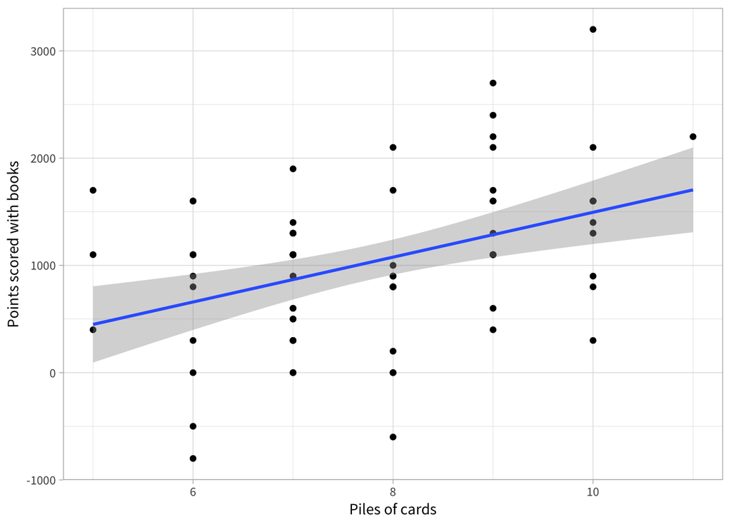

```r
ggplot(filter(round.details, !is.na(piles)), aes(x=piles, y=score_books)) +
  geom_point() +
  geom_smooth(method="lm") +
  labs(x="Piles of cards", y="Points scored with books")
```

### Card points and piles

```r
cards.piles <- lm(score_cards ~ piles, data=round.details) %>% tidy()
```

The number of piles you play is also (obviously) correlated with the number of card points you score. Playing an additional set of cards will give you an expected increase of 55 points, on average.

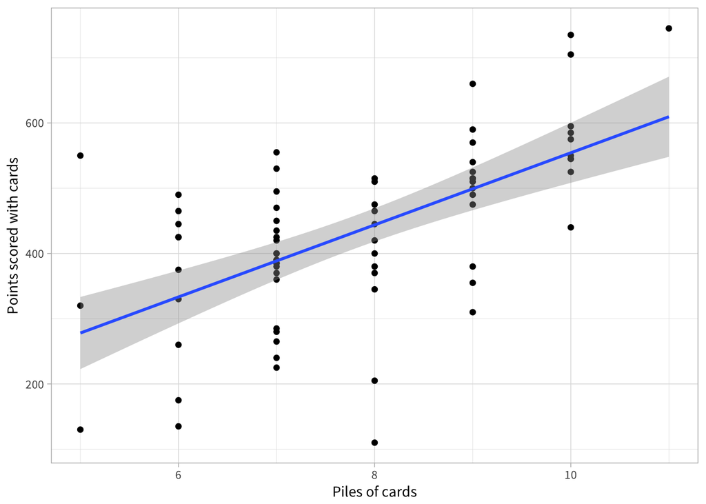

```r
ggplot(filter(round.details, !is.na(piles)), aes(x=piles, y=score_cards)) +
  geom_point() +
  geom_smooth(method="lm") +
  labs(x="Piles of cards", y="Points scored with cards")
```